# Using DB Browser for SQLite

### Launching DB Browser

- Windows - Use windows button (bottom left of screen), type in “DB Browser”
- Mac - Start DB Browser from applications folder

### The Initial Screen

**show on screen**

- start up window

#### Environment Overview

- A small `menu system` consisting of `File, Edit, View and Help`.
- Below the the menu system is a toolbar with four options; `New Database, Open Database, Write Changes and Revert Changes`.

Below the toolbar is a 4-tabbed pane for; `Database Structure, Browse Data, Edit Proagmas and Execute SQL`. Initially theese will be quite empty as we haven’t created or opened a database yet.

- In general we will see how each of these are used as we go through the lesson.
- except of the Edit Pragmas tab which deals with system wide parameters which we won’t want to change.
- On the right hand side therte are two further panes, at the top is the `Edit Database Cell` pane which is al greyed out.
- Below it is a 3-tabbed pane for DB Schema, SQL log and Remote.
- We are only really interested in the `DB Schema tab`

## Initial change to the layout

- Layout is quite flexible
- Drag and drop into positions
- individual tabs on the bottom pane closed directly from the pane and re-opened from the menu View item.

### Modify panes for lessons

- We will make a couple of initial changes to the layout of the screen.
- These will be retained across sessions.
1. From the View menu item un-select the `Edit Database Cell` icon to the left of the text. This will make the pane close and the bottom pane will be expanded automatically to fill the space.
2. From the `View menu` item select `preferences` and select the `Data Browser` tab.
- Towards the botton there is a section dealing with Field colors.
- You will see three bars below the word Text, to the right there are in fact three invisible bars for the Background.
- Click in the area for the `Backgroung color for NULL`.
- A color selector window will open, select `Red`.
- The bar will turn Red.
- This is now the default background cell colour that will be used to display `NULL` values in you tables.
- We will discuss the meaning of `NULL` values in a table in a later.
- close the preference window by clicking `OK`.

## Opening a database

- For this lesson we will be making extensive use of the SN7577 database.
- If you do not already have a copy of this database you can download it from here.

#### Download data

https://data-lessons.github.io/sql-socialsci/data/SN7577.sqlite

#### Database sn7577 info

https://discover.ukdataservice.ac.uk/#7577 * Title: Audit of Political Engagement 11, 2013 * Political behaviour and attitudes - Politics

To open the database in DB Browser do the following;

- clichk on the `open database` button in the toolbar.
- Navigate to where you have stored the database file on your local machine, select it and click open.
- When you open the database, the `Database Structure` tab on the left andthe `DB Schema` pane on the right will look very similar.
- However the `DB Schema` pane is only there to allow you to see the details of the schema for the tables.
- In particular what tables are in the database and the fields and their types which are in each table.
- The `Database Structure` tab on the left allows you to initiate actions on the tables.
- If you right click on a table name in the `DB Schema` pane, nothing happens.
- However, if you do the same in the `Database Structure` menu you will be given a set of possible actions.
- These are the same actions that are available from the toolbar at the top of the tab.
- If you select `Browse Table`, the data from the table is loaded into the `Browse Data` pane from where it can be examined or filtered.
- You can also select ther table you wish to Browse directly from here.
- There are options for `New Record` and `Delete Record`.
- It is unlikely that you will want to use these options.
- Our interest is in analysing exiosting data not creating or deleting data.

## Running SQL Queries

- We will be running queries extensively in future episodes.
- For now we will just provide an outline of the environment.
- In the left hand pane if you select the `Execute SQL` tab, you will be presented with a three paned window and a small toolbar.
- The top pane is itself tabbed with the initial tab labeled `SQL 1`.
- This is the SQL editor pane into which you will type your queries.

On the toolbar there are five buttons. Left to right they are:

- Open Tab (creates a new tab in the editor)
- Open SQL file (allows you to load a prepared file of SQL into the editor - the tab takes the name of he file)
- Save SQL file (allows you to save the current contents of the active pane to the local file system)
- Execute SQL (Executes all of the SQL statements in the editor pane)
- Execute current line (Actually executes whatever is selected)
- Because it is possible to have and execute multiple SQL statements in the same editor pane, each must be terminated with a `;`.
- If you only have a single statement you don’t need it, but it might be considered best practice to always include it.
- The pane below the editor is the Results pane.
- The results of running your query will appear here in a simple tabular format.
- The bottom pane is for messages about the execution, either an error message or an indication of how many rows were returned by the query.
- Below is a simple examople query and the results.

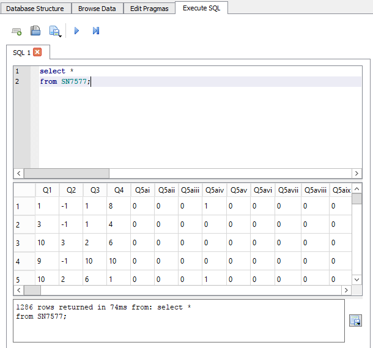

- Notice that the queryhas been written over multiple lines.
- This is commonly done to aid readability.
- The second pane has the tabular results, and the bottom pane has a message indicating how many rows were returned, how long it took and a copy of the SQL statement that was executed.
- To the right of the bottom pane is a single button which will provideyou with options about what you can do with the output.
- This includes saving it to a `csv` file.

### Creating a database

- As well as opening (connecting) to existing databases it is also possible to create new SQLite databases and tables using DB Browser.
- To create a database click the `New Database` button from the main toolbar (also available from the File menu).
- You will initially be asked for a name for the database and where you want to save it. It is saved as a single file.
- You can choose your own extension but `sqlite` is recommended.
- If you do not provide a default, then a `.db` extension will be used.
- Although the new database is empty, in that there are no tables in it, the .sqlite file itself is not empty.
- Once you have saved the databae file the `Create Table wizard` will open allowing you to create a table.
- You can cancel this as we will be going through the create table process in a later episode.

### Write Changes & Revert Changes

- During your DB Browser session, if you create or delete any tables the changes are not automatically written to the database file.
- When you try to end the session (i.e. close the application) you will be asked if you want to save the changes you have made.
- Alternatively you can explicitly save changes or revert changes during a session by use of the Write Changes and Revert Changes buttons on the toolbar.
- Once written the changes are permanent (there is no concept of multiple `undo` like you might have in other programs).
- Revert Changes will take you back to the last Written copy.

### Key Points

- The DB Browser for SQLite application allows you to connect to an existing database or create a new database
- When connected to a database you can create new tables
- When connected to a database you can write and run SQL queries and view the results
- You can save the reults of a query to a file